# Cx43 puncta vs protein expression

2024-02-19 09:54:00

# Overview

Here we will perform pairwise comparisons of all variables in dataset comprising:

- ordinal variables from the donor metadata (Age, PD.duration, LB.Braak.stage, SN.depigmentation, Amyloid.pathology, Tau.pathology, Vessel.disease…CAA)
- protein expression from the Western Blot experiments
- Cx43 puncta counts from the confocal images

Correlation matrices will be generated for:

- all donors (PD and control)
- PD only
- control only

# Load libraries

```r
library(stringr)
library(corrplot)
library(Hmisc)
```

# Load data

```r
donors <- read.csv("../data/donor_metadata.csv", row.names=1, na.strings="NA")

puncta <- read.csv("../data/Cx43 puncta per cell - Sheet1.csv", header=T, na.string="NA")
puncta <- puncta[c(18:29, 10:17, 1:9, 30:40),]
row.names(puncta) <- puncta$Donor.ID
puncta$Donor.ID <- NULL

wb <- read.csv("../data/WB_protein_levels.csv", row.names=1)
wb <- wb[c(21:40,1:20),]

group <- c(rep("P", 20),rep("C", 20))
```

# All donors

We will ignore the variables PD.duration and SN.depigmentation, because these are not available for controls.

```r
dataAll <- cbind(donors$Age, donors$LB.Braak.stage, donors$Amyloid.pathology, donors$Tau.pathology, donors$Vessel.disease...CAA,puncta,wb)

names(dataAll) <- c(
  "Age",
  "LB.Braak.stage",
  "Amyloid.pathology",
  "Tau.pathology",
  "Vessel.disease...CAA",
  "Puncta.Frontal.cortex",
  "Puncta.Parietal.cortex",
  "Puncta.Insular.cortex",
  "Puncta.BG.Putamen",
  "Puncta.BG.Globus.P",
  "Puncta.BG.Caudate",
  "Puncta.Midbrain.SN",
  "WB.ParCort.Cx43",
  "WB.ParCort.GFAP",
  "WB.ParCort.ALdh1L1",
  "WB.ParCort.GDNF",
  "WB.StriBG.Cx43",
  "WB.StriBG.GFAP",
  "WB.StriBG.ALdh1L1",
  "WB.StriBG.GDNF",
  "WB.MidSN.Cx43",
  "WB.MidSN.GFAP",
  "WB.MidSN.ALdh1L1",
  "WB.MidSN.GDNF"
)
```

Remove columns (variables) we don’t want to analyse:

```r
dataAll$Age <- NULL
dataAll$LB.Braak.stage <- NULL
dataAll$Amyloid.pathology <- NULL
dataAll$Tau.pathology <- NULL
dataAll$Vessel.disease...CAA <- NULL
dataAll$WB.ParCort.GFAP <- NULL
dataAll$WB.ParCort.ALdh1L1 <- NULL
dataAll$WB.ParCort.GDNF <- NULL
dataAll$WB.StriBG.ALdh1L1 <- NULL
dataAll$WB.StriBG.GDNF <- NULL
dataAll$WB.StriBG.GFAP <- NULL
dataAll$WB.MidSN.ALdh1L1 <- NULL
dataAll$WB.MidSN.GDNF <- NULL
dataAll$WB.MidSN.GFAP <- NULL
```

We’ll use Spearman’s rho statistic which measures the strength and direction of any monotonic association between two variables. N.B. relationship does not need to be linear.

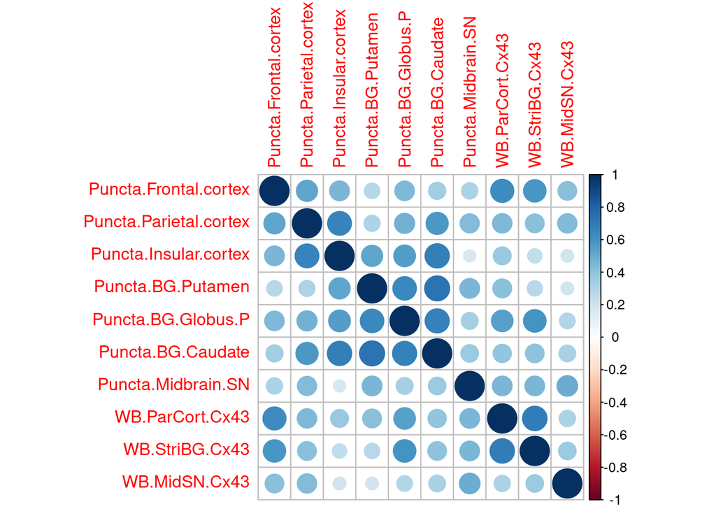

```r
#corMatAll <- rcorr(dataAll, use="pairwise.complete.obs", method="spearman")
corMatAll <- rcorr(as.matrix(dataAll), type="spearman")
corrplot(corMatAll$r, method="circle")
```

```r
corMatAllTable <- round(corMatAll$r, 3)
corMatAllTable[upper.tri(corMatAllTable, diag=TRUE)] <- ""
corMatAllP <- round(corMatAll$P, 3)
corMatAllP <- ifelse(corMatAllP==0, "<0.001", corMatAllP)
corMatAllTable[upper.tri(corMatAllTable)] <- corMatAllP[upper.tri(corMatAllP)]
knitr::kable(corMatAllTable, caption="Correlation coefficients (Spearman's rho) are below the diagonal and p-values are above the diagonal.")
```

Correlation coefficients (Spearman’s rho) are below the diagonal and p-values are above the diagonal.

|  | Puncta.Frontal.cortex | Puncta.Parietal.cortex | Puncta.Insular.cortex | Puncta.BG.Putamen | Puncta.BG.Globus.P | Puncta.BG.Caudate | Puncta.Midbrain.SN | WB.ParCort.Cx43 | WB.StriBG.Cx43 | WB.MidSN.Cx43 |
| --- | --- | --- | --- | --- | --- | --- | --- | --- | --- | --- |
| Puncta.Frontal.cortex |  | 0.001 | 0.004 | 0.081 | 0.011 | 0.067 | 0.049 | <0.001 | <0.001 | 0.01 |
| Puncta.Parietal.cortex | 0.52 |  | <0.001 | 0.061 | 0.007 | 0.001 | 0.006 | 0.005 | 0.009 | 0.007 |
| Puncta.Insular.cortex | 0.458 | 0.661 |  | 0.001 | 0.001 | <0.001 | 0.294 | 0.021 | 0.139 | 0.247 |
| Puncta.BG.Putamen | 0.283 | 0.306 | 0.526 |  | <0.001 | <0.001 | 0.003 | 0.008 | 0.086 | 0.243 |
| Puncta.BG.Globus.P | 0.448 | 0.472 | 0.553 | 0.646 |  | <0.001 | 0.065 | 0.002 | <0.001 | 0.118 |
| Puncta.BG.Caudate | 0.345 | 0.572 | 0.688 | 0.731 | 0.679 |  | 0.052 | 0.036 | 0.027 | 0.087 |
| Puncta.Midbrain.SN | 0.313 | 0.43 | 0.175 | 0.459 | 0.335 | 0.364 |  | 0.003 | 0.003 | 0.002 |
| WB.ParCort.Cx43 | 0.623 | 0.441 | 0.372 | 0.417 | 0.545 | 0.391 | 0.454 |  | <0.001 | 0.055 |
| WB.StriBG.Cx43 | 0.586 | 0.412 | 0.245 | 0.278 | 0.593 | 0.409 | 0.452 | 0.698 |  | 0.026 |
| WB.MidSN.Cx43 | 0.41 | 0.439 | 0.195 | 0.194 | 0.291 | 0.329 | 0.495 | 0.314 | 0.362 |  |

```r
fdrP <- round(p.adjust(corMatAll$P[upper.tri(corMatAll$P)], method="BH"),3)
fdrP <- ifelse(fdrP==0, "<0.001", fdrP)
n_fdr <- corMatAll$n
n_fdr[upper.tri(n_fdr, diag=TRUE)] <- ""
n_fdr[upper.tri(n_fdr)] <- fdrP
knitr::kable(n_fdr, caption="The number of observations used in analyzing each pair of variables is displayed below the diagonal and the FDR adjusted p-value above.")
```

The number of observations used in analyzing each pair of variables is displayed below the diagonal and the FDR adjusted p-value above.

|  | Puncta.Frontal.cortex | Puncta.Parietal.cortex | Puncta.Insular.cortex | Puncta.BG.Putamen | Puncta.BG.Globus.P | Puncta.BG.Caudate | Puncta.Midbrain.SN | WB.ParCort.Cx43 | WB.StriBG.Cx43 | WB.MidSN.Cx43 |
| --- | --- | --- | --- | --- | --- | --- | --- | --- | --- | --- |
| Puncta.Frontal.cortex |  | 0.003 | 0.009 | 0.096 | 0.019 | 0.081 | 0.069 | <0.001 | 0.001 | 0.018 |
| Puncta.Parietal.cortex | 39 |  | <0.001 | 0.079 | 0.014 | 0.004 | 0.013 | 0.011 | 0.017 | 0.014 |
| Puncta.Insular.cortex | 38 | 38 |  | 0.003 | 0.004 | <0.001 | 0.294 | 0.034 | 0.149 | 0.252 |
| Puncta.BG.Putamen | 39 | 38 | 38 |  | 0.001 | <0.001 | 0.009 | 0.015 | 0.098 | 0.252 |
| Puncta.BG.Globus.P | 31 | 31 | 31 | 31 |  | 0.002 | 0.081 | 0.005 | 0.002 | 0.13 |
| Puncta.BG.Caudate | 29 | 29 | 29 | 29 | 23 |  | 0.071 | 0.052 | 0.041 | 0.098 |
| Puncta.Midbrain.SN | 40 | 39 | 38 | 39 | 31 | 29 |  | 0.009 | 0.009 | 0.005 |
| WB.ParCort.Cx43 | 40 | 39 | 38 | 39 | 31 | 29 | 40 |  | <0.001 | 0.072 |
| WB.StriBG.Cx43 | 40 | 39 | 38 | 39 | 31 | 29 | 40 | 40 |  | 0.04 |
| WB.MidSN.Cx43 | 38 | 37 | 37 | 38 | 30 | 28 | 38 | 38 | 38 |  |

# Donors with Parkison’s Disease

```r
dataPD <- cbind(donors$Age, donors$PD.duration, donors$LB.Braak.stage, donors$SN.depigmentation, donors$Amyloid.pathology, donors$Tau.pathology, donors$Vessel.disease...CAA,puncta,wb)[group=="P",]

names(dataPD) <- c(
  "Age",
  "PD.duration",
  "LB.Braak.stage",
  "SN.depigmentation",
  "Amyloid.pathology",
  "Tau.pathology",
  "Vessel.disease...CAA",
  "Puncta.Frontal.cortex",
  "Puncta.Parietal.cortex",
  "Puncta.Insular.cortex",
  "Puncta.BG.Putamen",
  "Puncta.BG.Globus.P",
  "Puncta.BG.Caudate",
  "Puncta.Midbrain.SN",
  "WB.ParCort.Cx43",
  "WB.ParCort.GFAP",
  "WB.ParCort.ALdh1L1",
  "WB.ParCort.GDNF",
  "WB.StriBG.Cx43",
  "WB.StriBG.GFAP",
  "WB.StriBG.ALdh1L1",
  "WB.StriBG.GDNF",
  "WB.MidSN.Cx43",
  "WB.MidSN.GFAP",
  "WB.MidSN.ALdh1L1",
  "WB.MidSN.GDNF"
)
```

Remove columns (variables) we don’t want to analyse:

```r
dataPD$Age <- NULL
dataPD$LB.Braak.stage <- NULL
dataPD$Amyloid.pathology <- NULL
dataPD$Tau.pathology <- NULL
dataPD$Vessel.disease...CAA <- NULL
dataPD$SN.depigmentation <- NULL
dataPD$PD.duration <- NULL
dataPD$WB.ParCort.GFAP <- NULL
dataPD$WB.ParCort.ALdh1L1 <- NULL
dataPD$WB.ParCort.GDNF <- NULL
dataPD$WB.StriBG.ALdh1L1 <- NULL
dataPD$WB.StriBG.GDNF <- NULL
dataPD$WB.StriBG.GFAP <- NULL
dataPD$WB.MidSN.ALdh1L1 <- NULL
dataPD$WB.MidSN.GDNF <- NULL
dataPD$WB.MidSN.GFAP <- NULL
```

We’ll use Spearman’s rho statistic which measures the strength and direction of any monotonic association between two variables. N.B. relationship does not need to be linear.

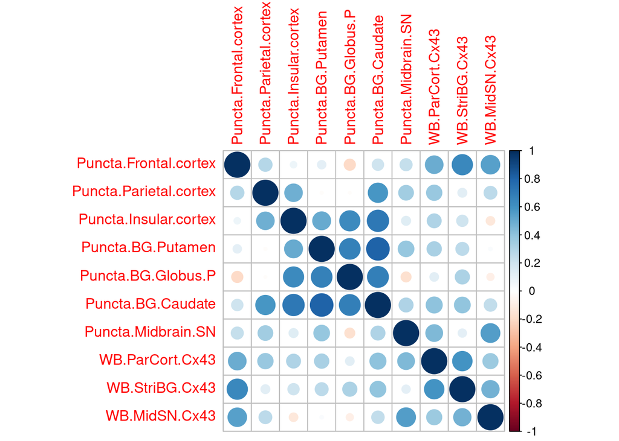

```r
#corMatPD <- cor(dataPD, use="pairwise.complete.obs", method="spearman")
corMatPD <- rcorr(as.matrix(dataPD), type="spearman")
corrplot(corMatPD$r, method="circle")
```

```r
corMatPDTable <- round(corMatPD$r, 3)
corMatPDTable[upper.tri(corMatPDTable, diag=TRUE)] <- ""
corMatPDP <- round(corMatPD$P, 3)
corMatPDP <- ifelse(corMatPDP==0, "<0.001", corMatPDP)
corMatPDTable[upper.tri(corMatPDTable)] <- corMatPDP[upper.tri(corMatPDP)]
knitr::kable(corMatPDTable, caption="Correlation coefficients (Spearman's rho) are below the diagonal and p-values are above the diagonal.")
```

Correlation coefficients (Spearman’s rho) are below the diagonal and p-values are above the diagonal.

|  | Puncta.Frontal.cortex | Puncta.Parietal.cortex | Puncta.Insular.cortex | Puncta.BG.Putamen | Puncta.BG.Globus.P | Puncta.BG.Caudate | Puncta.Midbrain.SN | WB.ParCort.Cx43 | WB.StriBG.Cx43 | WB.MidSN.Cx43 |
| --- | --- | --- | --- | --- | --- | --- | --- | --- | --- | --- |
| Puncta.Frontal.cortex |  | 0.23 | 0.767 | 0.627 | 0.475 | 0.474 | 0.323 | 0.028 | 0.002 | 0.013 |
| Puncta.Parietal.cortex | 0.281 |  | 0.029 | 0.94 | 0.96 | 0.027 | 0.139 | 0.107 | 0.591 | 0.265 |
| Puncta.Insular.cortex | 0.071 | 0.487 |  | 0.023 | 0.01 | 0.004 | 0.578 | 0.188 | 0.387 | 0.613 |
| Puncta.BG.Putamen | 0.116 | -0.018 | 0.505 |  | 0.006 | 0.001 | 0.091 | 0.162 | 0.254 | 0.92 |
| Puncta.BG.Globus.P | -0.2 | -0.014 | 0.639 | 0.671 |  | 0.029 | 0.567 | 0.666 | 0.248 | 0.761 |
| Puncta.BG.Caudate | 0.209 | 0.587 | 0.714 | 0.802 | 0.685 |  | 0.281 | 0.149 | 0.164 | 0.392 |
| Puncta.Midbrain.SN | 0.233 | 0.343 | 0.132 | 0.388 | -0.161 | 0.31 |  | 0.05 | 0.636 | 0.011 |
| WB.ParCort.Cx43 | 0.49 | 0.371 | 0.307 | 0.325 | 0.121 | 0.407 | 0.444 |  | 0.006 | 0.116 |
| WB.StriBG.Cx43 | 0.647 | 0.128 | 0.205 | 0.268 | 0.318 | 0.393 | 0.113 | 0.594 |  | 0.036 |
| WB.MidSN.Cx43 | 0.543 | 0.262 | -0.12 | 0.024 | -0.086 | 0.248 | 0.558 | 0.362 | 0.472 |  |

```r
fdrP <- round(p.adjust(corMatPD$P[upper.tri(corMatPD$P)], method="BH"),3)
fdrP <- ifelse(fdrP==0, "<0.001", fdrP)
n_fdr <- corMatPD$n
n_fdr[upper.tri(n_fdr, diag=TRUE)] <- ""
n_fdr[upper.tri(n_fdr)] <- fdrP
knitr::kable(n_fdr, caption="The number of observations used in analyzing each pair of variables is displayed below the diagonal and the FDR adjusted p-value above.")
```

The number of observations used in analyzing each pair of variables is displayed below the diagonal and the FDR adjusted p-value above.

|  | Puncta.Frontal.cortex | Puncta.Parietal.cortex | Puncta.Insular.cortex | Puncta.BG.Putamen | Puncta.BG.Globus.P | Puncta.BG.Caudate | Puncta.Midbrain.SN | WB.ParCort.Cx43 | WB.StriBG.Cx43 | WB.MidSN.Cx43 |
| --- | --- | --- | --- | --- | --- | --- | --- | --- | --- | --- |
| Puncta.Frontal.cortex |  | 0.431 | 0.822 | 0.734 | 0.647 | 0.647 | 0.501 | 0.102 | 0.046 | 0.075 |
| Puncta.Parietal.cortex | 20 |  | 0.102 | 0.96 | 0.96 | 0.102 | 0.329 | 0.283 | 0.734 | 0.442 |
| Puncta.Insular.cortex | 20 | 20 |  | 0.102 | 0.068 | 0.055 | 0.734 | 0.368 | 0.569 | 0.734 |
| Puncta.BG.Putamen | 20 | 20 | 20 |  | 0.055 | 0.025 | 0.256 | 0.336 | 0.439 | 0.96 |
| Puncta.BG.Globus.P | 15 | 15 | 15 | 15 |  | 0.102 | 0.734 | 0.75 | 0.439 | 0.822 |
| Puncta.BG.Caudate | 14 | 14 | 14 | 14 | 10 |  | 0.451 | 0.335 | 0.336 | 0.569 |
| Puncta.Midbrain.SN | 20 | 20 | 20 | 20 | 15 | 14 |  | 0.15 | 0.734 | 0.068 |
| WB.ParCort.Cx43 | 20 | 20 | 20 | 20 | 15 | 14 | 20 |  | 0.055 | 0.291 |
| WB.StriBG.Cx43 | 20 | 20 | 20 | 20 | 15 | 14 | 20 | 20 |  | 0.114 |
| WB.MidSN.Cx43 | 20 | 20 | 20 | 20 | 15 | 14 | 20 | 20 | 20 |  |

# Control group

We will ignore the variables PD.duration and SN.depigmentation, because these are not available for controls. We’ll also ignore LB.Braak.stage, because this is zero or NA for all control donors

```r
dataControl <- cbind(donors$Age, donors$Amyloid.pathology, donors$Tau.pathology, donors$Vessel.disease...CAA,puncta,wb)[group=="C",]

names(dataControl) <- c(
  "Age",
  "Amyloid.pathology",
  "Tau.pathology",
  "Vessel.disease...CAA",
  "Puncta.Frontal.cortex",
  "Puncta.Parietal.cortex",
  "Puncta.Insular.cortex",
  "Puncta.BG.Putamen",
  "Puncta.BG.Globus.P",
  "Puncta.BG.Caudate",
  "Puncta.Midbrain.SN",
  "WB.ParCort.Cx43",
  "WB.ParCort.GFAP",
  "WB.ParCort.ALdh1L1",
  "WB.ParCort.GDNF",
  "WB.StriBG.Cx43",
  "WB.StriBG.GFAP",
  "WB.StriBG.ALdh1L1",
  "WB.StriBG.GDNF",
  "WB.MidSN.Cx43",
  "WB.MidSN.GFAP",
  "WB.MidSN.ALdh1L1",
  "WB.MidSN.GDNF"
)
```

Remove columns (variables) we don’t want to analyse:

```r
dataControl$Age <- NULL
dataControl$Amyloid.pathology <- NULL
dataControl$Tau.pathology <- NULL
dataControl$Vessel.disease...CAA <- NULL
dataControl$WB.ParCort.GFAP <- NULL
dataControl$WB.ParCort.ALdh1L1 <- NULL
dataControl$WB.ParCort.GDNF <- NULL
dataControl$WB.StriBG.ALdh1L1 <- NULL
dataControl$WB.StriBG.GDNF <- NULL
dataControl$WB.StriBG.GFAP <- NULL
dataControl$WB.MidSN.ALdh1L1 <- NULL
dataControl$WB.MidSN.GDNF <- NULL
dataControl$WB.MidSN.GFAP <- NULL
```

We’ll use Spearman’s rho statistic which measures the strength and direction of any monotonic association between two variables. N.B. relationship does not need to be linear.

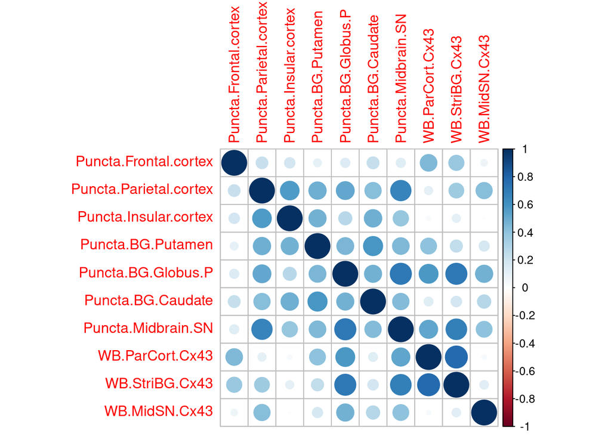

```r
#corMatControl <- cor(dataControl, use="pairwise.complete.obs", method="spearman")
corMatControl <- rcorr(as.matrix(dataControl), type="spearman")
corrplot(corMatControl$r, method="circle")
```

```r
corMatControlTable <- round(corMatControl$r, 3)
corMatControlTable[upper.tri(corMatControlTable, diag=TRUE)] <- ""
corMatControlP <- round(corMatControl$P, 3)
corMatControlP <- ifelse(corMatControlP==0, "<0.001", corMatControlP)
corMatControlTable[upper.tri(corMatControlTable)] <- corMatControlP[upper.tri(corMatControlP)]
knitr::kable(corMatControlTable, caption="Correlation coefficients (Spearman's rho) are below the diagonal and p-values are above the diagonal.")
```

Correlation coefficients (Spearman’s rho) are below the diagonal and p-values are above the diagonal.

|  | Puncta.Frontal.cortex | Puncta.Parietal.cortex | Puncta.Insular.cortex | Puncta.BG.Putamen | Puncta.BG.Globus.P | Puncta.BG.Caudate | Puncta.Midbrain.SN | WB.ParCort.Cx43 | WB.StriBG.Cx43 | WB.MidSN.Cx43 |
| --- | --- | --- | --- | --- | --- | --- | --- | --- | --- | --- |
| Puncta.Frontal.cortex |  | 0.351 | 0.473 | 0.668 | 0.602 | 0.405 | 0.561 | 0.048 | 0.107 | 0.766 |
| Puncta.Parietal.cortex | 0.226 |  | 0.016 | 0.042 | 0.041 | 0.111 | 0.002 | 0.647 | 0.137 | 0.09 |
| Puncta.Insular.cortex | 0.181 | 0.56 |  | 0.046 | 0.295 | 0.064 | 0.119 | 0.887 | 0.663 | 0.955 |
| Puncta.BG.Putamen | 0.105 | 0.484 | 0.476 |  | 0.074 | 0.021 | 0.055 | 0.082 | 0.322 | 0.499 |
| Puncta.BG.Globus.P | 0.141 | 0.515 | 0.279 | 0.459 |  | 0.103 | 0.002 | 0.02 | 0.002 | 0.071 |
| Puncta.BG.Caudate | 0.232 | 0.429 | 0.489 | 0.589 | 0.473 |  | 0.108 | 0.639 | 0.516 | 0.318 |
| Puncta.Midbrain.SN | 0.138 | 0.663 | 0.381 | 0.447 | 0.718 | 0.432 |  | 0.017 | 0.001 | 0.095 |
| WB.ParCort.Cx43 | 0.448 | 0.112 | 0.036 | 0.409 | 0.574 | 0.132 | 0.528 |  | <0.001 | 0.893 |
| WB.StriBG.Cx43 | 0.371 | 0.354 | 0.11 | 0.24 | 0.715 | 0.182 | 0.684 | 0.779 |  | 0.622 |
| WB.MidSN.Cx43 | 0.075 | 0.424 | 0.015 | 0.17 | 0.479 | 0.288 | 0.406 | 0.034 | 0.125 |  |

```r
fdrP <- round(p.adjust(corMatControl$P[upper.tri(corMatControl$P)], method="BH"),3)
fdrP <- ifelse(fdrP==0, "<0.001", fdrP)
n_fdr <- corMatControl$n
n_fdr[upper.tri(n_fdr, diag=TRUE)] <- ""
n_fdr[upper.tri(n_fdr)] <- fdrP
knitr::kable(n_fdr, caption="The number of observations used in analyzing each pair of variables is displayed below the diagonal and the FDR adjusted p-value above.")
```

The number of observations used in analyzing each pair of variables is displayed below the diagonal and the FDR adjusted p-value above.

|  | Puncta.Frontal.cortex | Puncta.Parietal.cortex | Puncta.Insular.cortex | Puncta.BG.Putamen | Puncta.BG.Globus.P | Puncta.BG.Caudate | Puncta.Midbrain.SN | WB.ParCort.Cx43 | WB.StriBG.Cx43 | WB.MidSN.Cx43 |
| --- | --- | --- | --- | --- | --- | --- | --- | --- | --- | --- |
| Puncta.Frontal.cortex |  | 0.527 | 0.666 | 0.733 | 0.733 | 0.588 | 0.721 | 0.165 | 0.208 | 0.821 |
| Puncta.Parietal.cortex | 19 |  | 0.104 | 0.165 | 0.165 | 0.208 | 0.018 | 0.733 | 0.236 | 0.208 |
| Puncta.Insular.cortex | 18 | 18 |  | 0.165 | 0.491 | 0.192 | 0.214 | 0.914 | 0.733 | 0.955 |
| Puncta.BG.Putamen | 19 | 18 | 18 |  | 0.195 | 0.104 | 0.176 | 0.206 | 0.499 | 0.681 |
| Puncta.BG.Globus.P | 16 | 16 | 16 | 16 |  | 0.208 | 0.018 | 0.104 | 0.018 | 0.195 |
| Puncta.BG.Caudate | 15 | 15 | 15 | 15 | 13 |  | 0.208 | 0.733 | 0.683 | 0.499 |
| Puncta.Midbrain.SN | 20 | 19 | 18 | 19 | 16 | 15 |  | 0.104 | 0.018 | 0.208 |
| WB.ParCort.Cx43 | 20 | 19 | 18 | 19 | 16 | 15 | 20 |  | 0.002 | 0.914 |
| WB.StriBG.Cx43 | 20 | 19 | 18 | 19 | 16 | 15 | 20 | 20 |  | 0.733 |
| WB.MidSN.Cx43 | 18 | 17 | 17 | 18 | 15 | 14 | 18 | 18 | 18 |  |

# References

```r
citation()
```

```
##
##   R Core Team (2023). _R: A Language and Environment for Statistical
##   Computing_. R Foundation for Statistical Computing, Vienna, Austria.
##   <https://www.R-project.org/>.
##
## A BibTeX entry for LaTeX users is
##
##   @Manual{,
##     title = {R: A Language and Environment for Statistical Computing},
##     author = {{R Core Team}},
##     organization = {R Foundation for Statistical Computing},
##     address = {Vienna, Austria},
##     year = {2023},
##     url = {https://www.R-project.org/},
##   }
##
## We have invested a lot of time and effort in creating R, please cite it
## when using it for data analysis. See also 'citation("pkgname")' for
## citing R packages.
```

```r
citation("stringr")
```

```
##
##   Wickham H (2023). _stringr: Simple, Consistent Wrappers for Common
##   String Operations_. R package version 1.5.1,
##   <https://CRAN.R-project.org/package=stringr>.
##
## A BibTeX entry for LaTeX users is
##
##   @Manual{,
##     title = {stringr: Simple, Consistent Wrappers for Common String Operations},
##     author = {Hadley Wickham},
##     year = {2023},
##     note = {R package version 1.5.1},
##     url = {https://CRAN.R-project.org/package=stringr},
##   }
```

```r
citation("corrplot")
```

```
##
##   Taiyun Wei and Viliam Simko (2021). R package 'corrplot':
##   Visualization of a Correlation Matrix (Version 0.92). Available from
##   https://github.com/taiyun/corrplot
##
## A BibTeX entry for LaTeX users is
##
##   @Manual{corrplot2021,
##     title = {R package 'corrplot': Visualization of a Correlation Matrix},
##     author = {Taiyun Wei and Viliam Simko},
##     year = {2021},
##     note = {(Version 0.92)},
##     url = {https://github.com/taiyun/corrplot},
##   }
```

```r
citation("Hmisc")
```

```
##
##   Harrell Jr F (2023). _Hmisc: Harrell Miscellaneous_. R package
##   version 5.1-1, <https://CRAN.R-project.org/package=Hmisc>.
##
## A BibTeX entry for LaTeX users is
##
##   @Manual{,
##     title = {Hmisc: Harrell Miscellaneous},
##     author = {Frank E {Harrell Jr}},
##     year = {2023},
##     note = {R package version 5.1-1},
##     url = {https://CRAN.R-project.org/package=Hmisc},
##   }
```